# FinEcon2_PS2

Bjorn Jivung

2026-01-17

## Step 0: Global knit options and a clean session

This chunk sets consistent R Markdown behavior and wipes the workspace so every run starts from a clean slate.

```r
# Knit behavior (controls how code + outputs appear in the rendered document)

knitr::opts_chunk$set(
echo    = TRUE,   # show code in the knitted output
warning = TRUE,   # keep warnings visible while developing
message = TRUE    # show messages (e.g., package startup); can switch to FALSE later
)

# Start from a clean workspace

rm(list = ls())     # remove all objects in the Global Environment
gc()                # garbage collection: frees memory
```

```
##           used (Mb) gc trigger (Mb) max used (Mb)
## Ncells  611633 32.7    1396485 74.6   702074 37.5
## Vcells 1143915  8.8    8388608 64.0  1927979 14.8
```

```r
# Reproducibility / print settings

options(stringsAsFactors = FALSE)  # consistent behavior across R versions
options(scipen = 999)              # reduce scientific notation in printed numbers
set.seed(123)                      # reproducibility for anything stochastic
```

##Step 0.1: Install and load the packages for this project

This chunk installs (if needed) and loads the libraries used in PS2 (event study, Bacon–Goodman decomposition, and imputation-style DID).

```r
# Make installs non-interactive and consistent

options(repos = c(CRAN = "[https://cloud.r-project.org](https://cloud.r-project.org)"))

# Package list for this project (based on PS2 requirements)

pkgs <- c(

# Data import and wrangling

"data.table", "dplyr", "tidyr", "readr", "haven",
"stringr", "janitor", "lubridate",

# Visualization

"ggplot2", "scales",

# Fixed effects, inference, and output

"fixest", "broom", "modelsummary",
"lmtest", "sandwich", "clubSandwich",

# Difference-in-differences tools

"bacondecomp",      # Goodman–Bacon decomposition
"did",              # Callaway & Sant’Anna
"didimputation",    # Borusyak et al. imputation estimator

# Utilities

"here", "rstudioapi"
)

# Install any packages that are missing

missing_pkgs <- pkgs[!pkgs %in% rownames(installed.packages())]

if (length(missing_pkgs) > 0) {
install.packages(missing_pkgs, type = "binary")
}

# Load all packages

invisible(lapply(pkgs, library, character.only = TRUE))
```

```
## here() starts at C:/Users/jivung3/Desktop/FE2_PS2/FinEcon2_PS2
```

```r
# Quick version check for key econometrics packages

cat("\nKey package versions:\n")
```

```
##
## Key package versions:
```

```r
cat("fixest:        ", as.character(packageVersion("fixest")), "\n")
```

```
## fixest:         0.13.2
```

```r
cat("bacondecomp:   ", as.character(packageVersion("bacondecomp")), "\n")
```

```
## bacondecomp:    0.1.1
```

```r
cat("did:           ", as.character(packageVersion("did")), "\n")
```

```
## did:            2.3.0
```

```r
cat("didimputation: ", as.character(packageVersion("didimputation")), "\n")
```

```
## didimputation:  0.3.0
```

## Step 0.2: Set the project root and define standard folder paths

This chunk defines a reliable project root directory and creates/records the key folders used throughout the project so all file paths stay consistent and relative.

```r
# Project root and path management (single source of truth)

# Use the active RStudio Project path if available; otherwise fall back to the current working directory

PROJECT_DIR <- NA_character_

if (rstudioapi::isAvailable()) {
proj <- tryCatch(rstudioapi::getActiveProject(), error = function(e) NA_character_)
if (!is.na(proj) && nzchar(proj)) PROJECT_DIR <- proj
}

if (is.na(PROJECT_DIR) || !nzchar(PROJECT_DIR)) {
PROJECT_DIR <- getwd()
}

PROJECT_DIR <- normalizePath(PROJECT_DIR, winslash = "/")
cat("Project directory:\n", PROJECT_DIR, "\n")
```

```
## Project directory:
##  C:/Users/jivung3/Desktop/FE2_PS2/FinEcon2_PS2
```

```r
# Define standard folders (edit/add as needed later)

DATA_RAW_DIR   <- file.path(PROJECT_DIR, "data_raw")
DATA_CLEAN_DIR <- file.path(PROJECT_DIR, "data_clean")
R_DIR          <- file.path(PROJECT_DIR, "R")
ANALYSIS_DIR   <- file.path(PROJECT_DIR, "analysis")
OUTPUT_DIR     <- file.path(PROJECT_DIR, "output")
FIG_DIR        <- file.path(OUTPUT_DIR, "figures")
TAB_DIR        <- file.path(OUTPUT_DIR, "tables")

# Create folders safely (no warnings if they already exist)

dir.create(DATA_RAW_DIR,   recursive = TRUE, showWarnings = FALSE)
dir.create(DATA_CLEAN_DIR, recursive = TRUE, showWarnings = FALSE)
dir.create(R_DIR,          recursive = TRUE, showWarnings = FALSE)
dir.create(ANALYSIS_DIR,   recursive = TRUE, showWarnings = FALSE)
dir.create(FIG_DIR,        recursive = TRUE, showWarnings = FALSE)
dir.create(TAB_DIR,        recursive = TRUE, showWarnings = FALSE)

# Quick sanity checks: list the main project folders

cat("\nFolder paths:\n")
```

```
##
## Folder paths:
```

```r
cat("DATA_RAW_DIR:   ", DATA_RAW_DIR, "\n")
```

```
## DATA_RAW_DIR:    C:/Users/jivung3/Desktop/FE2_PS2/FinEcon2_PS2/data_raw
```

```r
cat("DATA_CLEAN_DIR: ", DATA_CLEAN_DIR, "\n")
```

```
## DATA_CLEAN_DIR:  C:/Users/jivung3/Desktop/FE2_PS2/FinEcon2_PS2/data_clean
```

```r
cat("R_DIR:          ", R_DIR, "\n")
```

```
## R_DIR:           C:/Users/jivung3/Desktop/FE2_PS2/FinEcon2_PS2/R
```

```r
cat("ANALYSIS_DIR:   ", ANALYSIS_DIR, "\n")
```

```
## ANALYSIS_DIR:    C:/Users/jivung3/Desktop/FE2_PS2/FinEcon2_PS2/analysis
```

```r
cat("OUTPUT_DIR:     ", OUTPUT_DIR, "\n")
```

```
## OUTPUT_DIR:      C:/Users/jivung3/Desktop/FE2_PS2/FinEcon2_PS2/output
```

```r
cat("FIG_DIR:        ", FIG_DIR, "\n")
```

```
## FIG_DIR:         C:/Users/jivung3/Desktop/FE2_PS2/FinEcon2_PS2/output/figures
```

```r
cat("TAB_DIR:        ", TAB_DIR, "\n")
```

```
## TAB_DIR:         C:/Users/jivung3/Desktop/FE2_PS2/FinEcon2_PS2/output/tables
```

```r
# Confirm they exist

stopifnot(
dir.exists(DATA_RAW_DIR),
dir.exists(DATA_CLEAN_DIR),
dir.exists(R_DIR),
dir.exists(ANALYSIS_DIR),
dir.exists(OUTPUT_DIR),
dir.exists(FIG_DIR),
dir.exists(TAB_DIR)
)
```

## Step 0.3: Git diagnostics and repository status checks

This chunk verifies that Git is installed, confirms the project is a Git repository, and prints key repo info (branch + remotes).

```r
# Git diagnostics (confirm Git works and this folder is a repo)

git_version <- tryCatch(system("git --version", intern = TRUE), error = function(e) character(0))

if (length(git_version) == 0) {
cat("Git status: NOT FOUND\n")
cat("Fix: Install Git and restart RStudio so Git is available in your PATH.\n\n")
} else {
cat("Git status: FOUND\n")
cat("Git version:\n", paste(git_version, collapse = "\n"), "\n\n", sep = "")
}
```

```
## Git status: FOUND
## Git version:
## git version 2.52.0.windows.1
```

```r
# Check whether we are inside a Git repository

git_toplevel <- tryCatch(system("git rev-parse --show-toplevel", intern = TRUE), error = function(e) character(0))

if (length(git_toplevel) == 0) {
cat("Repository status: NOT a Git repository (no .git detected)\n")
cat("If needed, initialize from the project folder in a Terminal:\n")
cat("  git init\n  git branch -M main\n\n")
} else {
cat("Repository status: Git repository detected\n")
cat("Repo top-level folder:\n", paste(git_toplevel, collapse = "\n"), "\n\n", sep = "")

# Current branch

branch <- tryCatch(system("git branch --show-current", intern = TRUE), error = function(e) character(0))
if (length(branch) > 0) cat("Current branch: ", branch, "\n\n", sep = "")

# Remote(s)

remotes <- tryCatch(system("git remote -v", intern = TRUE), error = function(e) character(0))
if (length(remotes) == 0) {
cat("Remotes: none configured yet\n")
cat("If you created a GitHub repo, add it like:\n")
cat("  git remote add origin <YOUR_GITHUB_URL>\n\n")
} else {
cat("Remotes:\n", paste(remotes, collapse = "\n"), "\n\n", sep = "")
}

# Quick status snapshot

status <- tryCatch(system("git status -sb", intern = TRUE), error = function(e) character(0))
if (length(status) > 0) cat("git status (short):\n", paste(status, collapse = "\n"), "\n", sep = "")
}
```

```
## Repository status: Git repository detected
## Repo top-level folder:
## C:/Users/jivung3/Desktop/FE2_PS2/FinEcon2_PS2
##
## Current branch: main
##
## Remotes:
## origin   https://github.com/Bjorn-Free/FinEcon2_PS2 (fetch)
## origin   https://github.com/Bjorn-Free/FinEcon2_PS2 (push)
##
## git status (short):
## ## main...origin/main
##  M Main.Rmd
```

## Step 0.4: Define key file names and centralize data paths

This chunk defines the main data file names in one place so that all later code refers to these objects rather than hard-coding file paths.

```r
# Centralized file names (edit once here, use everywhere else)

# Main dataset (raw and cleaned versions)

MAIN_DATA_RAW   <- file.path(DATA_RAW_DIR,   "main_dataset_raw.csv")
MAIN_DATA_CLEAN <- file.path(DATA_CLEAN_DIR, "main_dataset_clean.csv")

# Optional: auxiliary files you may add later

FLOOD_DATA_RAW   <- file.path(DATA_RAW_DIR,   "flood_events_raw.csv")
FLOOD_DATA_CLEAN <- file.path(DATA_CLEAN_DIR, "flood_events_clean.csv")

# Print for sanity check

cat("Key data file paths:\n")
```

```
## Key data file paths:
```

```r
cat("MAIN_DATA_RAW:   ", MAIN_DATA_RAW, "\n")
```

```
## MAIN_DATA_RAW:    C:/Users/jivung3/Desktop/FE2_PS2/FinEcon2_PS2/data_raw/main_dataset_raw.csv
```

```r
cat("MAIN_DATA_CLEAN: ", MAIN_DATA_CLEAN, "\n")
```

```
## MAIN_DATA_CLEAN:  C:/Users/jivung3/Desktop/FE2_PS2/FinEcon2_PS2/data_clean/main_dataset_clean.csv
```

```r
cat("FLOOD_DATA_RAW:  ", FLOOD_DATA_RAW, "\n")
```

```
## FLOOD_DATA_RAW:   C:/Users/jivung3/Desktop/FE2_PS2/FinEcon2_PS2/data_raw/flood_events_raw.csv
```

```r
cat("FLOOD_DATA_CLEAN:", FLOOD_DATA_CLEAN, "\n")
```

```
## FLOOD_DATA_CLEAN: C:/Users/jivung3/Desktop/FE2_PS2/FinEcon2_PS2/data_clean/flood_events_clean.csv
```

```r
# Existence checks (non-fatal for now, since data may not be added yet)

if (!file.exists(MAIN_DATA_RAW)) {
cat("\nNOTE: MAIN_DATA_RAW does not exist yet (expected if data not added).\n")
}
```

```
##
## NOTE: MAIN_DATA_RAW does not exist yet (expected if data not added).
```

```r
if (!file.exists(FLOOD_DATA_RAW)) {
cat("NOTE: FLOOD_DATA_RAW does not exist yet (expected if data not added).\n")
}
```

```
## NOTE: FLOOD_DATA_RAW does not exist yet (expected if data not added).
```

## Step 0.5: Load the raw dataset and run basic sanity checks

This chunk loads the raw Stata dataset and prints basic information (size, variables, structure).

```r
# Load the raw PS2 dataset

PS2_DATA_RAW <- file.path(DATA_RAW_DIR, "PS2_data.dta")

cat("Attempting to load data from:\n", PS2_DATA_RAW, "\n")
```

```
## Attempting to load data from:
##  C:/Users/jivung3/Desktop/FE2_PS2/FinEcon2_PS2/data_raw/PS2_data.dta
```

```r
if (!file.exists(PS2_DATA_RAW)) {
stop("Data file not found at the specified path. Check DATA_RAW_DIR and filename.")
}

ps2_raw <- haven::read_dta(PS2_DATA_RAW)

# Basic structure checks

cat("\nDataset loaded successfully.\n")
```

```
##
## Dataset loaded successfully.
```

```r
cat("Dimensions (rows, columns):\n")
```

```
## Dimensions (rows, columns):
```

```r
print(dim(ps2_raw))
```

```
## [1] 126342      5
```

```r
cat("\nVariable names:\n")
```

```
##
## Variable names:
```

```r
print(names(ps2_raw))
```

```
## [1] "state"       "id_num"      "year"        "hityear"     "ln_policies"
```

```r
cat("\nFirst 10 rows:\n")
```

```
##
## First 10 rows:
```

```r
print(head(ps2_raw, 10))
```

```
## # A tibble: 10 × 5
##    state   id_num  year hityear ln_policies
##    <chr>    <dbl> <dbl>   <dbl>       <dbl>
##  1 ALABAMA  10010  1990       0       -5.65
##  2 ALABAMA  10010  1991       0       -5.68
##  3 ALABAMA  10010  1992       0       -5.71
##  4 ALABAMA  10010  1993       0       -5.73
##  5 ALABAMA  10010  1994       0       -5.73
##  6 ALABAMA  10010  1995       0       -5.73
##  7 ALABAMA  10010  1996       0       -5.04
##  8 ALABAMA  10010  1997       0       -5.05
##  9 ALABAMA  10010  1998       0       -5.06
## 10 ALABAMA  10010  1999       0       -5.05
```

```r
# Quick panel sanity checks

cat("\nUnique communities (id_num): ", length(unique(ps2_raw$id_num)), "\n")
```

```
##
## Unique communities (id_num):  7019
```

```r
cat("Unique years: ", length(unique(ps2_raw$year)), "\n")
```

```
## Unique years:  18
```

```r
# Check for duplicate id-year pairs (should generally be none)

dup_check <- ps2_raw %>%
count(id_num, year) %>%
filter(n > 1)

if (nrow(dup_check) == 0) {
cat("\nNo duplicate (id_num, year) pairs found.\n")
} else {
cat("\nWARNING: Duplicate (id_num, year) pairs detected:\n")
print(dup_check)
}
```

```
##
## No duplicate (id_num, year) pairs found.
```

```r
# Check how hityear is coded

cat("\nSummary of hityear variable:\n")
```

```
##
## Summary of hityear variable:
```

```r
print(table(ps2_raw$hityear, useNA = "ifany"))
```

```
##
##      0      1
## 123250   3092
```

```r
# Check how many floods per community (should be at most once by assignment design)

floods_per_id <- ps2_raw %>%
group_by(id_num) %>%
summarise(total_floods = sum(hityear == 1, na.rm = TRUE))

cat("\nDistribution of number of floods per community:\n")
```

```
##
## Distribution of number of floods per community:
```

```r
print(table(floods_per_id$total_floods))
```

```
##
##    0    1
## 3927 3092
```

## Part b) Event-study estimation around flood timing

Part (b) is completed by constructing event time relative to each community’s flood year, estimating a TWFE event-study regression with fixed effects, and plotting the coefficients with confidence intervals. Interpretation focuses on dynamics before and after the flood and on appropriate clustering choices.

## Step B.1: Create a clean working dataset and confirm basic structure

This chunk creates a working copy of the raw data and enforces consistent variable types needed for the event-time construction and fixed-effects regressions.

```r
# Create a working copy (keeps the raw object untouched)

ps2 <- ps2_raw

# Enforce consistent types (fixest prefers clean integer / factor structure)

ps2 <- ps2 %>%
mutate(
state       = as.character(state),
id_num      = as.integer(id_num),
year        = as.integer(year),
hityear     = as.integer(hityear),
ln_policies = as.numeric(ln_policies)
)

# Basic structure checks (lightweight, intended to fail fast if something is off)

cat("Rows, columns:\n")
```

```
## Rows, columns:
```

```r
print(dim(ps2))
```

```
## [1] 126342      5
```

```r
cat("\nYear range:\n")
```

```
##
## Year range:
```

```r
print(range(ps2$year, na.rm = TRUE))
```

```
## [1] 1990 2007
```

```r
cat("\nUnique communities (id_num):\n")
```

```
##
## Unique communities (id_num):
```

```r
print(length(unique(ps2$id_num)))
```

```
## [1] 7019
```

```r
cat("\nUnique states:\n")
```

```
##
## Unique states:
```

```r
print(length(unique(ps2$state)))
```

```
## [1] 48
```

```r
cat("\nCheck hityear coding (should be 0/1 only):\n")
```

```
##
## Check hityear coding (should be 0/1 only):
```

```r
print(table(ps2$hityear, useNA = "ifany"))
```

```
##
##      0      1
## 123250   3092
```

```r
# Confirm panel uniqueness at the id-year level (should be exactly one observation per pair)

dup_id_year <- ps2 %>%
count(id_num, year) %>%
filter(n > 1)

stopifnot(nrow(dup_id_year) == 0)
```

## Step B.2: Construct each community’s flood year and merge it back to the panel

This chunk creates a community-level flood_year (the year with hityear == 1, if any) and merges it back into the full panel dataset.

```r
# Construct the flood year for each community (NA for never-flooded communities)

flood_year_by_id <- ps2 %>%
group_by(id_num) %>%
summarise(
flood_year = ifelse(any(hityear == 1, na.rm = TRUE),
year[which(hityear == 1)[1]],
NA_integer_),
.groups = "drop"
)

# Merge back to the main panel

ps2 <- ps2 %>%
left_join(flood_year_by_id, by = "id_num")

# Sanity checks

cat("Communities with a flood year:\n")
```

```
## Communities with a flood year:
```

```r
print(sum(!is.na(ps2$flood_year)) / length(ps2$flood_year))  # share at observation level (not id-level)
```

```
## [1] 0.4405186
```

```r
cat("\nUnique flood years (treated communities only):\n")
```

```
##
## Unique flood years (treated communities only):
```

```r
print(sort(unique(ps2$flood_year[!is.na(ps2$flood_year)])))
```

```
##  [1] 1990 1991 1992 1993 1994 1995 1996 1997 1998 1999 2000 2001 2002 2003 2004
## [16] 2005 2006 2007
```

```r
# Check floods-per-community is still at most one (assignment design)

floods_per_id <- ps2 %>%
group_by(id_num) %>%
summarise(total_floods = sum(hityear == 1, na.rm = TRUE), .groups = "drop")

cat("\nDistribution of floods per community (should be 0 or 1 only):\n")
```

```
##
## Distribution of floods per community (should be 0 or 1 only):
```

```r
print(table(floods_per_id$total_floods, useNA = "ifany"))
```

```
##
##    0    1
## 3927 3092
```

```r
stopifnot(all(floods_per_id$total_floods %in% c(0, 1)))
```

## Step B.3: Construct treatment status and relative event time

This chunk creates a treated indicator and the relative year variable𝑟= year − flood_year for treated communities, plus quick checks of the resulting event-time support.

```r
# Treated indicator and relative event time

ps2 <- ps2 %>%
mutate(
treated  = as.integer(!is.na(flood_year)),
rel_year = ifelse(treated == 1, year - flood_year, NA_integer_)
)

# Sanity checks at the community level (not observation level)

treated_share_ids <- ps2 %>%
distinct(id_num, flood_year) %>%
summarise(treated_share = mean(!is.na(flood_year))) %>%
pull(treated_share)

cat("Share of communities treated (should be 3092 / 7019):\n")
```

```
## Share of communities treated (should be 3092 / 7019):
```

```r
print(treated_share_ids)
```

```
## [1] 0.4405186
```

```r
cat("\nCheck treated indicator (observation-level counts):\n")
```

```
##
## Check treated indicator (observation-level counts):
```

```r
print(table(ps2$treated, useNA = "ifany"))
```

```
##
##     0     1
## 70686 55656
```

```r
# Relative year support for treated observations only

cat("\nRelative year summary (treated observations only):\n")
```

```
##
## Relative year summary (treated observations only):
```

```r
print(summary(ps2$rel_year[ps2$treated == 1]))
```

```
##    Min. 1st Qu.  Median    Mean 3rd Qu.    Max.
## -17.000  -7.000  -2.000  -1.791   3.000  17.000
```

```r
cat("\nRelative year frequency (treated observations only; first few):\n")
```

```
##
## Relative year frequency (treated observations only; first few):
```

```r
print(head(sort(table(ps2$rel_year[ps2$treated == 1])), 15))
```

```
##
##   17   16   15  -17   14   13  -16   12  -15   11   10    9  -14  -13    8
##  102  176  197  441  479  496  600  613  798  921 1151 1193 1264 1368 1401
```

## Step b.4: Choose event window and bin/cap relative time

This chunk defines the event-study window, bins extreme leads and lags, and creates a factor variable with the correct reference period (r = −1).

```r
# Choose event-study window

LOWER <- -6
UPPER <-  6

ps2 <- ps2 %>%
mutate(
rel_year_bin = case_when(
treated == 0              ~ NA_integer_,   # never-treated: no event time
rel_year <= LOWER         ~ LOWER,          # bin lower tail
rel_year >= UPPER         ~ UPPER,          # bin upper tail
TRUE                      ~ rel_year
)
)

# Check distribution after binning (treated only)

cat("Relative year (binned) distribution, treated observations only:\n")
```

```
## Relative year (binned) distribution, treated observations only:
```

```r
print(sort(table(ps2$rel_year_bin[ps2$treated == 1]), decreasing = TRUE))
```

```
##
##    -6     6     0    -1    -2    -3     1    -4    -5     2     3     4     5
## 17810  9755  3092  2990  2916  2895  2651  2613  2596  2492  2294  1828  1724
```

```r
# Create ordered factor for regression and plotting

event_levels <- sort(unique(ps2$rel_year_bin[ps2$treated == 1]))
ps2$rel_year_f <- factor(ps2$rel_year_bin, levels = event_levels)

# Set reference period: r = -1

ps2$rel_year_f <- relevel(ps2$rel_year_f, ref = "-1")

cat("\nEvent-time factor levels (in order):\n")
```

```
##
## Event-time factor levels (in order):
```

```r
print(levels(ps2$rel_year_f))
```

```
##  [1] "-1" "-6" "-5" "-4" "-3" "-2" "0"  "1"  "2"  "3"  "4"  "5"  "6"
```

```r
# Sanity check: confirm -1 is the reference

cat("\nReference level:\n")
```

```
##
## Reference level:
```

```r
print(levels(ps2$rel_year_f)[1] == "-1")
```

```
## [1] TRUE
```

## Step B.5: Estimate the event-study regression (Gallagher-style)

This chunk runs the TWFE event-study regression with: - Outcome: ln_policies - Event-time indicators: rel_year_f - Fixed effects: community FE and state-by-year FE - Clustering: by state (to match Gallagher)

```r
# Event-study regression: Gallagher-style specification

es_gallagher <- fixest::feols(
ln_policies ~ i(rel_year_f, treated, ref = "-1") |
id_num + state^year,
data    = ps2,
cluster = ~ state
)
```

```
## NOTES: 70,686 observations removed because of NA values (RHS: 70,686).
##        0/54 fixed-effect singletons were removed (54 observations).
```

```r
# Print regression summary (focus on event-time coefficients)

summary(es_gallagher)
```

```
## OLS estimation, Dep. Var.: ln_policies
## Observations: 55,602
## Fixed-effects: id_num: 3,089,  state^year: 810
## Standard-errors: Clustered (state)
##                         Estimate Std. Error   t value      Pr(>|t|)
## rel_year_f::-6:treated -0.015372   0.029318 -0.524329 0.60268123156
## rel_year_f::-5:treated -0.008112   0.023856 -0.340016 0.73546255731
## rel_year_f::-4:treated -0.014813   0.017983 -0.823702 0.41455151468
## rel_year_f::-3:treated -0.027331   0.013132 -2.081174 0.04326982470 *
## rel_year_f::-2:treated -0.002720   0.007847 -0.346636 0.73051703442
## rel_year_f::0:treated   0.090033   0.015331  5.872636 0.00000051914 ***
## rel_year_f::1:treated   0.118927   0.021876  5.436443 0.00000225493 ***
## rel_year_f::2:treated   0.100025   0.027314  3.662093 0.00066784575 ***
## rel_year_f::3:treated   0.094445   0.031224  3.024726 0.00414410036 **
## rel_year_f::4:treated   0.095251   0.031590  3.015270 0.00425236373 **
## rel_year_f::5:treated   0.086066   0.039780  2.163558 0.03597021639 *
## rel_year_f::6:treated   0.064034   0.051858  1.234799 0.22345882459
## ---
## Signif. codes:  0 '***' 0.001 '**' 0.01 '*' 0.05 '.' 0.1 ' ' 1
## RMSE: 0.402949     Adj. R2: 0.938938
##                  Within R2: 0.004584
```

```r
# Extract only the event-time coefficients for inspection

es_coefs <- broom::tidy(es_gallagher) %>%
filter(grepl("rel_year_f", term))

cat("\nEvent-time coefficients (relative to r = -1):\n")
```

```
##
## Event-time coefficients (relative to r = -1):
```

```r
print(es_coefs)
```

```
## # A tibble: 12 × 5
##    term                   estimate std.error statistic     p.value
##    <chr>                     <dbl>     <dbl>     <dbl>       <dbl>
##  1 rel_year_f::-6:treated -0.0154    0.0293     -0.524 0.603
##  2 rel_year_f::-5:treated -0.00811   0.0239     -0.340 0.735
##  3 rel_year_f::-4:treated -0.0148    0.0180     -0.824 0.415
##  4 rel_year_f::-3:treated -0.0273    0.0131     -2.08  0.0433
##  5 rel_year_f::-2:treated -0.00272   0.00785    -0.347 0.731
##  6 rel_year_f::0:treated   0.0900    0.0153      5.87  0.000000519
##  7 rel_year_f::1:treated   0.119     0.0219      5.44  0.00000225
##  8 rel_year_f::2:treated   0.100     0.0273      3.66  0.000668
##  9 rel_year_f::3:treated   0.0944    0.0312      3.02  0.00414
## 10 rel_year_f::4:treated   0.0953    0.0316      3.02  0.00425
## 11 rel_year_f::5:treated   0.0861    0.0398      2.16  0.0360
## 12 rel_year_f::6:treated   0.0640    0.0519      1.23  0.223
```

## Step B.6: Build and save the event-study plot

This chunk extracts the event-time coefficients from the regression, constructs confidence intervals, and plots the dynamic treatment effects relative to the year before the flood.

```r
# Tidy event-time coefficients from the Gallagher-style regression

es_plot_data <- broom::tidy(es_gallagher) %>%
filter(grepl("rel_year_f", term)) %>%
mutate(
rel_year = as.integer(gsub("rel_year_f::|:treated", "", term)),
ci_low   = estimate - 1.96 * std.error,
ci_high  = estimate + 1.96 * std.error
) %>%
arrange(rel_year)

# Print for a quick check

cat("Event-study plotting data:\n")
```

```
## Event-study plotting data:
```

```r
print(es_plot_data)
```

```
## # A tibble: 12 × 8
##    term          estimate std.error statistic p.value rel_year   ci_low  ci_high
##    <chr>            <dbl>     <dbl>     <dbl>   <dbl>    <int>    <dbl>    <dbl>
##  1 rel_year_f::… -0.0154    0.0293     -0.524 6.03e-1       -6 -0.0728   0.0421
##  2 rel_year_f::… -0.00811   0.0239     -0.340 7.35e-1       -5 -0.0549   0.0386
##  3 rel_year_f::… -0.0148    0.0180     -0.824 4.15e-1       -4 -0.0501   0.0204
##  4 rel_year_f::… -0.0273    0.0131     -2.08  4.33e-2       -3 -0.0531  -0.00159
##  5 rel_year_f::… -0.00272   0.00785    -0.347 7.31e-1       -2 -0.0181   0.0127
##  6 rel_year_f::…  0.0900    0.0153      5.87  5.19e-7        0  0.0600   0.120
##  7 rel_year_f::…  0.119     0.0219      5.44  2.25e-6        1  0.0761   0.162
##  8 rel_year_f::…  0.100     0.0273      3.66  6.68e-4        2  0.0465   0.154
##  9 rel_year_f::…  0.0944    0.0312      3.02  4.14e-3        3  0.0332   0.156
## 10 rel_year_f::…  0.0953    0.0316      3.02  4.25e-3        4  0.0333   0.157
## 11 rel_year_f::…  0.0861    0.0398      2.16  3.60e-2        5  0.00810  0.164
## 12 rel_year_f::…  0.0640    0.0519      1.23  2.23e-1        6 -0.0376   0.166
```

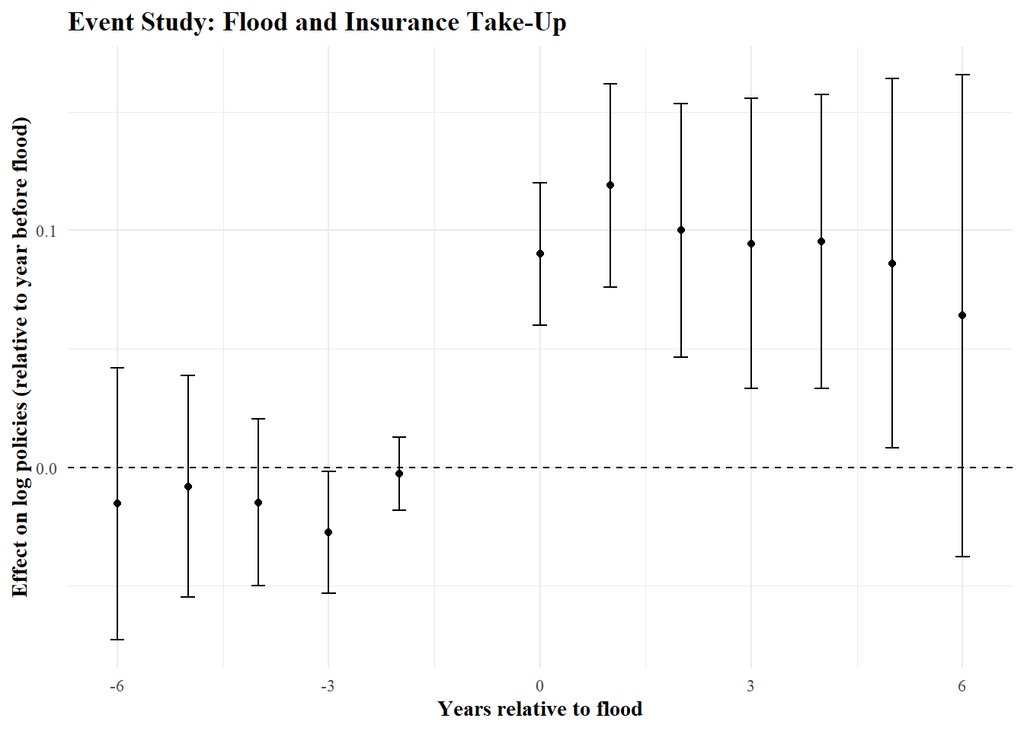

```r
# Build the event-study plot (serif = Times New Roman on Windows)

es_plot <- ggplot(es_plot_data, aes(x = rel_year, y = estimate)) +
geom_hline(yintercept = 0, linetype = "dashed") +
geom_point() +
geom_errorbar(aes(ymin = ci_low, ymax = ci_high), width = 0.2) +
labs(
x = "Years relative to flood",
y = "Effect on log policies (relative to year before flood)",
title = "Event Study: Flood and Insurance Take-Up"
) +
theme_minimal(base_family = "serif") +
theme(
plot.title = element_text(face = "bold"),
axis.title = element_text(face = "bold")
)

# Display the plot

print(es_plot)
```

```r
# Save the plot

plot_file <- file.path(FIG_DIR, "event_study_gallagher_style_serif.png")
ggsave(plot_file, es_plot, width = 7, height = 5, dpi = 300)

cat("Event-study figure saved to:\n", plot_file, "\n")
```

```
## Event-study figure saved to:
##  C:/Users/jivung3/Desktop/FE2_PS2/FinEcon2_PS2/output/figures/event_study_gallagher_style_serif.png
```

## Part b) i) Interpretation of the Event-Study Results

Figure B.6 shows the dynamic effect of a flood on log flood‐insurance take-up, normalized to zero in the year before the flood. Pre-treatment coefficients are generally small and statistically indistinguishable from zero, indicating little evidence of strong differential pre-trends once community fixed effects and state-by-year fixed effects are included. One lead (three years before the flood) is slightly negative and marginally significant, but there is no consistent pattern of divergence prior to treatment, supporting the identifying assumption that - conditional on fixed effects - the timing of floods is plausibly exogenous.

In contrast, the post-flood response is large and immediate. Insurance take-up rises by about 9 log points (roughly 9 percent) in the flood year and peaks around 12 log points in the following year. The effect then gradually declines but remains positive and statistically significant for several years, before becoming imprecisely estimated by about six years after the flood. This spike-and-decay pattern closely matches the dynamics emphasized in Gallagher: households strongly update beliefs after a recent flood, but the effect fades as the event becomes less salient, consistent with limited memory or overweighting of recent experience rather than full Bayesian learning.

## Part b) ii) Clustering of Standard Errors

Standard errors in the event-study regression are clustered at the state level, following Gallagher (2014). This choice is motivated by the likelihood that shocks affecting flood insurance demand—such as regulatory changes, insurance market conditions, or media coverage—are correlated across communities within the same state over time. Because treatment varies at the community level but key unobservables may be correlated at higher geographic levels, failing to account for this intra-state correlation would understate uncertainty and lead to over-rejection. Given that the specification also includes state-by-year fixed effects, clustering at the state level is a natural and coherent choice: it allows for arbitrary serial and cross-sectional correlation in the error term within states, while still exploiting within-state variation in flood timing across communities for identification.